# Time Series Data Analytics and Visualisation App’s Codes Report

Developer:** Vincent **Student ID:** 30052386 **Program**: Summer Vacation Research Scholarship Program **Project Title:** Time Series Data Analytics and Visualization App **Supervisors:** Dr. Pooia Lalbakhsh & Dr. Hao Wang **University**: Monash University Clayton **Date:** 22 February, 2023

### **Libraries / Packages**

```r
# Libraries / Packages
library(tidyverse) # Preliminary tidying package
library(naniar) # Missing data package
library(plotly) # Interactive plot package
library(ggplot2) # For data Visualization
library(e1071) # Calculate skewness
library(lubridate) # For date data type manipulation
library(caret) # Classification And REgression Training package
library(randomForest) # For fitting random forest model
library(earth) # For MARS Method (a.k.a. Multivariate Adaptive Regression Splines)
library(Boruta) # For Boruta Method
library(zoo) # For converting class dataframe object into class ts object (ts = time series)
```

### **Reading Data and Preparation**

**(RShiny App Lines: 36 - 69)**

This section will cover all raw datasets reading and preparation before using those datasets in the server environment. This demonstration of the application requires two datasets generated from the **Dataset Modification and Preprocessing Report** in the dataset_modification_and_preprocessing.ipynb file as follow:

1. time_series_df.csv (Section 3.4. Distribution, Missing Value, Outlier, and Trend Pages Dataset)
2. selection_df.csv (Section 3.5. Feature Selection Page and Random Forest Modelling Dataset)

These two datasets can be replaced with other time series datasets as long as the structure of the content follows the rules stated in the **Time Series Data Analytics and Visualization App User Guide and Random Forest Modelling of the Photovoltaic (PV) Generation Report section 2.1. Data Preparation**.

Following are the steps of this section:

- Reading data and modify the ReadTime variable structure into multiple helper variables (i.e., splitting ReadTime into date and time variables then further splitting date and time variables into some variables);
- Change the format of pv dataset object from wide format into longer format by using pivot_longer() function and stored it into the pv_data dataset object;
- Convert PVDate variable into Date data type -> for date filter in server environment of the RShiny App;
- Create raw data table -> for the Home page interactive table (pv_raw dataset object);
- Create small_df dataset object for the Missing Value page’s plot 5 (this dataset object will support us in using varSelectInput() function for gg_miss_fct() function in the server environment to filter by factor);
- Create selection_df dataset object for the feature selection part.

```r
# Reading Data and Preparation (RShiny App Lines: 36 - 69)

# Reading data and modify the ReadTime variable structure into multiple helper variables (i.e., splitting ReadTime into date and time variables then further splitting date and time variables into some variables)
pv <- as_tibble(read.csv(("./data/time_series_df.csv"))) %>%
  separate(ReadTime, into = c("PVdate", "PVtime"), sep = "\\s", extra = "merge", remove = FALSE) %>%
  separate(PVdate, into = c("dayofmonth", "month", "year"), sep = "/", extra = "merge", remove = FALSE) %>%
  separate(PVtime, into = c("timefactor", "AMorPM"), sep = "\\s", extra = "merge", remove = FALSE)

# pivot_longer all variables except the helper variables (i.e., observed variables)
pv_data <- pv %>%
  pivot_longer(cols = !c("ReadTime", "PVdate", "dayofmonth", "month", "year", "timefactor", "AMorPM", "PVtime"),
               names_to = "observed_variables",
               values_to = "observed_values")

# Convert PVDate variable into Date data type -> for date filter in server environment of the RShiny App
pv$PVdate <- as.Date(pv$PVdate, "%d/%m/%Y")
pv_data$PVdate <- as.Date(pv_data$PVdate, "%d/%m/%Y")

# Create raw data table -> for the Home page interactive table
pv_raw <- pv_data %>%
  dplyr::select(c(ReadTime, observed_variables, observed_values))

# Create small_df for the Missing Value page's plot 5 (because we need to use varSelectInput() for
# gg_miss_fct() function in the server environment to filter by factor)
small_df <- pv %>%
  dplyr::select(c(dayofmonth, month, year, AMorPM, PVtime))

# Create selection_df for the feature selection part
selection_df <- as_tibble(read.csv(("./data/selection_df.csv"))) %>%
  dplyr::select(!ReadTime)
```

### **Global View Codes for Filtering and Plot Parts (i.e., Server environment)**

This section will cover all the codes in the server environment for the Global View Page. To simplify the codes’ report, in this example, the inputs for each element in the Global View Page are as follow:

1. **Distribution:** Set LV_North_Pavilion.MSB_PV_DB from 2020-07-01 to 2021-07-16 and all time period as the inputs in the main filter (i.e., blue gear icon). Furthermore, the additional filter (i.e., red gear icon) sets the Remove Zero Observation(s) as “Yes”, Remove Negative Observation(s) as “Yes”, Remove Outlier(s) as “Yes, Z-Score Approach”, and Transformation Method as “Raw”;
2. **Missing Value:** Set LV_Sport_01.PVDB.DB.A, LV_Sport_01.PVDB.DB.B, LV_Sport_01.PVDB.MSSB, LV_North_Pavilion.MSB_PV_DB, and LV_Robert_Blackwood_Hall_2.Main_Solar_Supply from 2020-07-01 to 2021-07-16 and all time period in the main filter (i.e., blue gear icon);
3. **Outlier:** Set LV_North_Pavilion.MSB_PV_DB from 2020-07-01 to 2021-07-16 and all time period in the main filter (i.e., blue gear icon);
4. **Feature Selection:** Set pv_values as a response variable and the remaining variables as an explanatory variable (i.e., use full dataset) in the main filter (i.e., blue gear icon). For the Random Forest and Boruta methods, the app will use randomly sampled 10.000 observations from the big dataset (to reduce the expensive running time for the Random Forest and Boruta methods). This is our validation set. Furthermore, in the Random Forest method, the additional filter (i.e., red gear icon) sets the random forest’s parameters of 5 and 10 for mtry and ntree, respectively;
5. **Trend:** Set LV_North_Pavilion.MSB_PV_DB from 2020-07-01 to 2021-07-16 in the main filter (i.e., blue gear icon).

#### **Distribution Part (i.e., Server environment)**

**(RShiny App Lines: 1323 - 1528)**

```r
# Global View Codes for Filtering and Plot Parts (i.e., Server environment) (RShiny App Lines: 1323 - 1528)

                                    ##### Distribution Part #####

# (In this example, we will be using LV_North_Pavilion.MSB_PV_DB from 2020-07-01 to 2021-07-16 and all time period for the main filter (i.e., blue gear icon))

# Step 1. Create gvfiltered_df by filtering observed_variables, PVdate, and PVtime
gvfiltered_df <- pv_data %>%
  filter(observed_variables %in% c("LV_North_Pavilion.MSB_PV_DB")) %>% # filter observed_variables
  filter(between(PVdate, as.Date('2020-07-01'), as.Date('2021-07-16'))) %>% # filter PVdate
  filter(!(PVtime %in% c(""))) # filter PVtime

# Step 2. Missing Value DF
# Since it is a transformation method, we need to remove the missing values before plotting to avoid errors
gvrmv_na_df <- gvfiltered_df %>%
  # Remove NA(s) / Missing Value(s)
  na.omit()

# (The additional filter (i.e., red gear icon) sets the Remove Zero Observation(s) as "Yes", Remove Negative Observation(s) as "Yes", Remove Outlier(s) as "Yes, Z-Score Approach", and Transformation Method as "Raw".)

# Step 3. Remove Zero Observation(s) Option
gvrmv_zero_df <- gvfiltered_df %>%
  # Remove 0 observation(s)
  filter(observed_values != 0)

# Step 4. Remove Negative Value(s) Option
gvrmv_negative_df <- gvrmv_zero_df %>%
  # Remove negative value(s)
  filter(observed_values >= 0)

# Step 5. Remove Outlier(s) Option
temp_df <- gvrmv_negative_df

# Z-Score Calculation
right_tailz <- mean(temp_df$observed_values) + 3*sd(temp_df$observed_values)
left_tailz <- mean(temp_df$observed_values) - 3*sd(temp_df$observed_values)

# IQR Calculation
# Calculate IQR, Q3, and Q1
calc_iqr <- IQR(temp_df$observed_values)
q1 <- as.numeric(quantile(temp_df$observed_values, probs = 0.25))
q3 <- as.numeric(quantile(temp_df$observed_values, probs = 0.75))

right_taili <- q3 + 1.5 * calc_iqr
left_taili <- q1 - 1.5 * calc_iqr

gvrmv_outlier_df <- temp_df %>%
  # Remove outlier(s) with Z-Score method as an example
  filter(observed_values < right_tailz & observed_values > left_tailz)

# Step 6. Transformation Method Option
gvdused_df1 <- gvrmv_outlier_df %>%
  mutate(square_data = observed_values^2,
         cubic_data = observed_values^3,
         squareroot_data = sqrt(observed_values),
         cuberoot_data = observed_values^(1/3),
         logarithm10 = log10(observed_values),
         logarithmnat = log(observed_values))
```

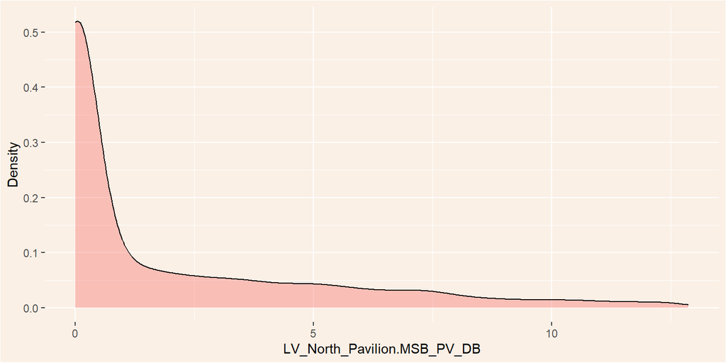

```r
# Step 7. Distribution of Density Plot
ggplot(data=gvdused_df1, aes(x=observed_values, fill="purple")) +
  geom_density(adjust=1.5, alpha=.4) +
  xlab(as.character("LV_North_Pavilion.MSB_PV_DB")) +
  ylab("Density") +
  theme(panel.background = element_rect(fill = "linen")) +
  theme(plot.background = element_rect(fill = "linen")) +
  theme(legend.position = "none")
```

```r
# Step 8. Distribution Plot's Descriptive Statistics

# Step 8.1. Variable Name
as.character("LV_North_Pavilion.MSB_PV_DB")
# [1] "LV_North_Pavilion.MSB_PV_DB"

# Step 8.2. Number of Observations
nrow(gvdused_df1)
# [1] 26656

# Step 8.3. Descriptive Statistics
summary(gvdused_df1$observed_values)
#    Min. 1st Qu.  Median    Mean 3rd Qu.    Max.
#   0.001   0.001   0.125   2.016   3.276  12.865

# Step 8.4. Standard Deviation
round(sd(gvdused_df1$observed_values), 3)
# [1] 3.054

# Step 8.5. Skewness
round(skewness(gvdused_df1$observed_values), 3)
# [1] 1.599
```

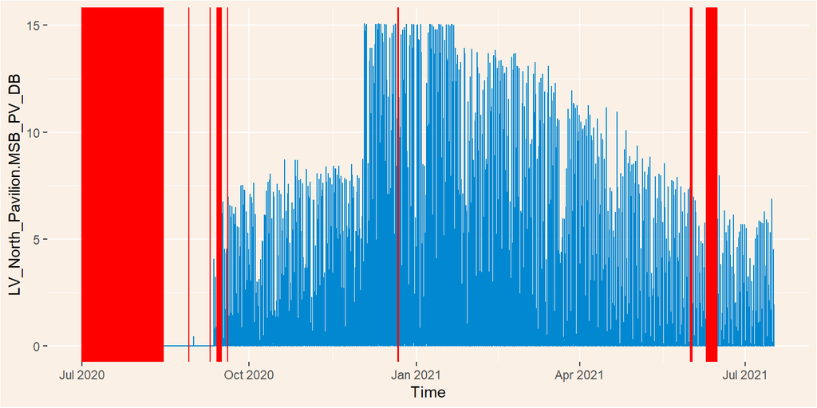

```r
# Step 9. Time Series Plot

# Step 9.a. Create datetime_df
# Step 9.1. Convert ReadTime into datetime data type by using Lubridate package
gvdatetime_df <- gvfiltered_df
gvdatetime_df$ReadTime <- dmy_hm(gvdatetime_df$ReadTime)

# Step 9.2. Create dummy if NA = Missing, and present = Present
gvdatetime_df$missing_dummy <- ifelse(is.na(gvdatetime_df$observed_values), "Missing", "Present")

# Step 9.b. Plotting (Without Interactive Feature)
ggplot(gvdatetime_df, aes(x = ReadTime, y = observed_values, group = 1)) +
      geom_line(color="#0288d1") +
      geom_vline(xintercept = gvdatetime_df$ReadTime[gvdatetime_df$missing_dummy == "Missing"], color = "red") +
      xlab("Time") +
      ylab("LV_North_Pavilion.MSB_PV_DB") +
      scale_color_discrete(name = "Status") +
      theme(panel.background = element_rect(fill = "linen")) +
      theme(plot.background = element_rect(fill = "linen"))
```

#### **Missing Value Part (i.e., Server environment)**

**(RShiny App Lines: 1530 - 1682)**

```r
                                    ##### Missing Value Part #####
## Missing Value Codes for Filtering and Plot Parts (i.e., Server environment) (RShiny App Lines: 1530 - 1682)

# (In this example we will be using LV_Sport_01.PVDB.DB.A, LV_Sport_01.PVDB.DB.B, LV_Sport_01.PVDB.MSSB, LV_North_Pavilion.MSB_PV_DB, and LV_Robert_Blackwood_Hall_2.Main_Solar_Supply from 2020-07-01 to 2021-07-16 and all time period)

# Step 1. Create gvmfiltered_df by filtering observed_variables, PVdate, and PVtime
gvmfiltered_df <- pv_data %>%
  filter(observed_variables %in% c("LV_Sport_01.PVDB.DB.A",
                                   "LV_Sport_01.PVDB.DB.B",
                                   "LV_Sport_01.PVDB.MSSB",
                                   "LV_North_Pavilion.MSB_PV_DB",
                                   "LV_Robert_Blackwood_Hall_2.Main_Solar_Supply")) %>% # filter observed_variables
  filter(between(PVdate, as.Date('2020-07-01'), as.Date('2021-07-16'))) %>% # filter Date
  filter(!(PVtime %in% c(""))) # filter PVtime

# Step 2. Creating Missing Value Table

# Step 2.1. Reformat gvmfiltered_df from long to wide format to calculate the number of missing rows easily
gvmfiltered_df_wider <- gvmfiltered_df %>%
  # Change from long into wide format
  pivot_wider(names_from = observed_variables, values_from = observed_values) %>%
  # Deselect helper variables
  dplyr::select(!c(PVdate, dayofmonth, month, year, timefactor, AMorPM, PVtime))

# Step 2.2. Creating Missing Value Dataframe
gvmmissing_df <- as_tibble(lapply(gvmfiltered_df_wider, function(x) sum(is.na(x)))) %>%
      gather(key = "variable_name", value = "missing_count") %>%
      # Calculate the total missing values category in the dataset
      bind_rows(summarise(.,
                          across(where(is.numeric), sum),
                          across(where(is.character), ~'Total')))

# Step 2.3. Send the output of missing_df in step 2.2. above to the frontend after filter out the Total category that we created previously
gvmmissing_df %>%
  # Filter out the Total category that we created previously
  filter(variable_name != "Total")
# # A tibble: 6 × 2
#   variable_name                                missing_count
#   <chr>                                                <int>
# 1 ReadTime                                                 0
# 2 LV_Sport_01.PVDB.DB.A                                 1393
# 3 LV_Sport_01.PVDB.DB.B                                16789
# 4 LV_Sport_01.PVDB.MSSB                                 3675
# 5 LV_North_Pavilion.MSB_PV_DB                           5167
# 6 LV_Robert_Blackwood_Hall_2.Main_Solar_Supply            22
```

```r
# Step 3. Missing Value Table's Descriptive Statistics

# Step 3.1. Create gvmfiltered_df_nona to count problematic row (i.e., there is an existence of missing values in one or more columns)
gvmfiltered_df_nona <- na.omit(gvmfiltered_df_wider) # Remove missing value in the gvmfiltered_df_wider dataframe to find # of rows that is fine (i.e., no missing value)

# Step 3.2. Number of observations
nrow(gvmfiltered_df_wider)
# [1] 36571

# Step 3.3. Total problematic rows
nrow(gvmfiltered_df_wider) - nrow(gvmfiltered_df_nona)
# [1] 24277

# Step 3.4. Proportion of problematic rows
x <- nrow(gvmfiltered_df_wider)
y <- nrow(gvmfiltered_df_wider) - nrow(gvmfiltered_df_nona)
z <- round((y / x) * 100, 2)

# Concatenate string
paste(as.character(z), "%", sep = "")
# [1] "66.38%"

# Step 3.5. Number of cells
nrow(gvmfiltered_df)
# [1] 182855

# Step 3.6. Total missing by the number of cells
as.integer(gvmmissing_df[gvmmissing_df$variable_name == "Total", "missing_count"])
# [1] 27046

# Step 3.7. Proportion of missing by the number of cells
x <- round(as.integer(gvmmissing_df[gvmmissing_df$variable_name == "Total", "missing_count"]) / nrow(gvmfiltered_df) * 100, 2)

# Concatenate string
paste(as.character(x), "%", sep = "")
# [1] "14.79%"
```

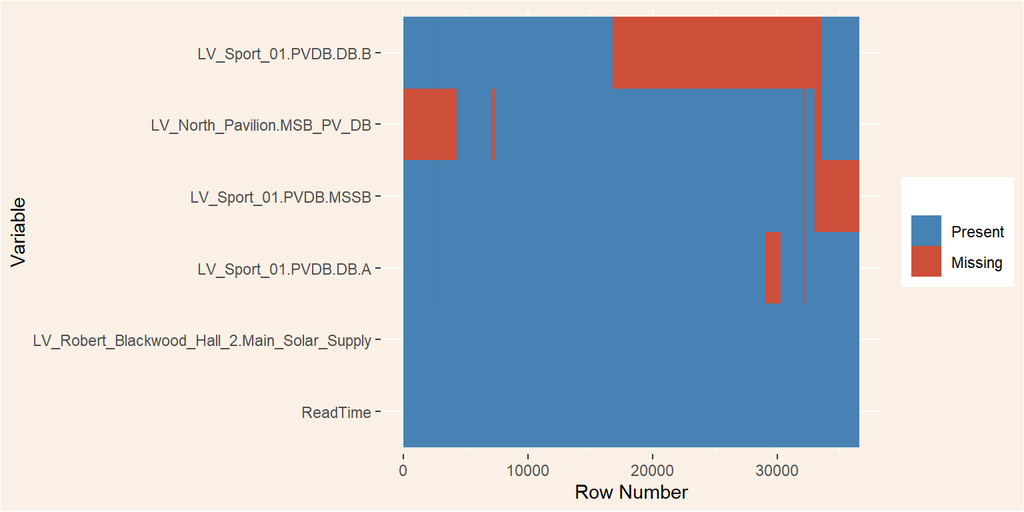

```r
# Step 4. Missing Value Plot 1 (Stacked Bar-Chart / Where the Missing Plot)

# Create new dataframe that include the calculation of proportion of the missing values for each variable
newdata <- gvmmissing_df %>%
  rename(Missing = missing_count) %>%
  filter(variable_name != "Total") %>%
  mutate(Present = nrow(gvmfiltered_df_wider) - Missing) %>%
  pivot_longer(cols = !c("variable_name"),
               names_to = "isna",
               values_to = "total_count") %>%
  mutate(pct = total_count / nrow(gvmfiltered_df_wider) * 100)

# Sort from highest to lowest
levels <-
  (newdata  %>% filter(isna == "Missing") %>% arrange(pct))$variable_name

# Plotting
gvmfiltered_df_wider %>%
  mutate(id = row_number()) %>%
  gather(-id, key = "key", value = "val") %>%
  mutate(isna = is.na(val)) %>%
  ggplot(aes(x = key, y = id, fill = isna)) +
  geom_tile() +
  scale_fill_manual(name = "",
                    values = c('steelblue', 'tomato3'),
                    labels = c("Present", "Missing"))  +
  scale_x_discrete(limits = levels) +
  labs(x = "Variable",
       y = "Row Number") +
  coord_flip() +
  theme(panel.background = element_rect(fill = "linen")) +
  theme(plot.background = element_rect(fill = "linen"))
```

#### **Outlier Part (i.e., Server environment)**

**(RShiny App Lines: 1684 - 1910)**

```r
                                    ##### Outlier Part #####
## Outlier Codes for Filtering and Plot Parts (i.e., Server environment) (RShiny App Lines: 1684 - 1910)

# (In this example, we will be using LV_North_Pavilion.MSB_PV_DB from 2020-07-01 to 2021-07-16 and all time period)

# Step 1. Create gvofiltered_df by filtering observed_variables, PVdate, and PVtime
gvofiltered_df <- pv_data %>%
  filter(observed_variables %in% c("LV_North_Pavilion.MSB_PV_DB")) %>% # filter observed_variables
  filter(between(PVdate, as.Date('2020-07-01'), as.Date('2021-07-16'))) %>% # filter PVdate
  filter(!(PVtime %in% c(""))) # filter PVtime

# Step 2. Create gvoused_df dataframe for plotting histograms and boxplots (after removing NAs)
gvoused_df <- gvofiltered_df %>%
  na.omit()
```

> **Z-Score Approach**

```r
                                      ##### Z-Score Approach #####

# Step 3. Interactive table description (Outlier -> Z-Score Approach)
right_tailz <- mean(gvoused_df$observed_values) + 3*sd(gvoused_df$observed_values)
left_tailz <- mean(gvoused_df$observed_values) - 3*sd(gvoused_df$observed_values)

gvoused_df %>%
  filter(observed_values > right_tailz | observed_values < left_tailz) %>%
  dplyr::select(ReadTime, observed_variables, observed_values)
# # A tibble: 844 × 3
#    ReadTime           observed_variables          observed_values
#    <chr>              <chr>                                 <dbl>
#  1 3/12/2020 10:15 AM LV_North_Pavilion.MSB_PV_DB            12.6
#  2 3/12/2020 10:30 AM LV_North_Pavilion.MSB_PV_DB            13.5
#  3 3/12/2020 10:45 AM LV_North_Pavilion.MSB_PV_DB            14.2
#  4 3/12/2020 11:00 AM LV_North_Pavilion.MSB_PV_DB            14.6
#  5 3/12/2020 11:15 AM LV_North_Pavilion.MSB_PV_DB            15.0
#  6 3/12/2020 11:30 AM LV_North_Pavilion.MSB_PV_DB            15.0
#  7 3/12/2020 11:45 AM LV_North_Pavilion.MSB_PV_DB            15.0
#  8 3/12/2020 12:00 PM LV_North_Pavilion.MSB_PV_DB            15.0
#  9 3/12/2020 12:15 PM LV_North_Pavilion.MSB_PV_DB            15.1
# 10 3/12/2020 12:30 PM LV_North_Pavilion.MSB_PV_DB            15.0
# # … with 834 more rows
```

```r
# Step 4. Z-Score Approach Table's Descriptive Statistics

# Step 4.1. Variable Name
as.character("LV_North_Pavilion.MSB_PV_DB")
# [1] "LV_North_Pavilion.MSB_PV_DB"

# Step 4.2. Descriptive Statistics
summary(gvofiltered_df$observed_values)
#    Min. 1st Qu.  Median    Mean 3rd Qu.    Max.    NA's
#   0.000   0.001   0.002   1.993   2.890  15.071    5167

# Step 4.3. Standard Deviation
round(sd(gvoused_df$observed_values), 3)
# [1] 3.375

# Step 4.4. Skewness before removing outliers
round(skewness(gvoused_df$observed_values), 3)
# [1] 1.933

# Step 4.5. Upper Limit: mean + 3 * stdev
round(mean(gvoused_df$observed_values) + 3*sd(gvoused_df$observed_values), 3)
# [1] 12.117

# Step 4.6. Lower Limit: mean - 3 * stdev
round(mean(gvoused_df$observed_values) - 3*sd(gvoused_df$observed_values), 3)
# [1] -8.132
```

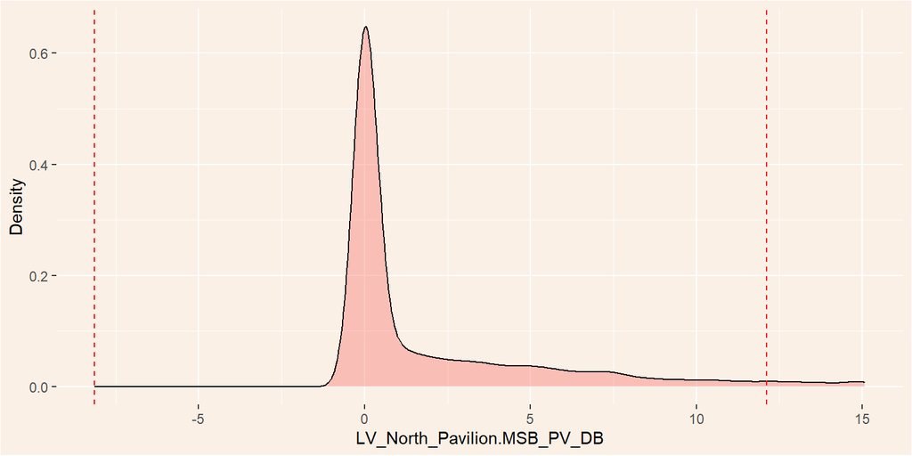

```r
# Step 5. Z-Score outlier density plot (before -> plot 1)
used_df <- gvoused_df

# Vertical line for the right and left tails
right_tailz <- mean(used_df$observed_values) + 3*sd(used_df$observed_values)
left_tailz <- mean(used_df$observed_values) - 3*sd(used_df$observed_values)

# Plotting
ggplot(data=used_df, aes(x=observed_values, fill="purple")) +
  geom_density(adjust=1.5, alpha=.4) +
  geom_vline(xintercept=right_tailz, linetype="dashed", color = "red") +
  geom_vline(xintercept=left_tailz, linetype="dashed", color = "red") +
  xlab("LV_North_Pavilion.MSB_PV_DB") +
  ylab("Density") +
  theme(panel.background = element_rect(fill = "linen")) +
  theme(plot.background = element_rect(fill = "linen")) +
  theme(legend.position = "none")
```

```r
# Step 6. Z-Score outlier boxplot (before -> plot 2)
used_df <- gvoused_df

# Plotting
used_df %>%
  ggplot(aes(x = observed_values, y = observed_variables)) +
  geom_boxplot(outlier.color="red") +
  labs(x = "Value",
       y = "Observed Variables") +
  theme(panel.background = element_rect(fill = "linen")) +
  theme(plot.background = element_rect(fill = "linen")) +
  theme(axis.text.y = element_text(angle = 90, vjust = 1, hjust=0.5))
```

[output not shown]

> **IQR Approach**

```r
                                      ##### IQR Approach #####

# Step 3. Interactive table description (Outlier -> IQR Approach)
# Calculate IQR, Q3, and Q1
calc_iqr <- IQR(gvoused_df$observed_values)
q1 <- as.numeric(quantile(gvoused_df$observed_values, probs = 0.25))
q3 <- as.numeric(quantile(gvoused_df$observed_values, probs = 0.75))

right_taili <- q3 + 1.5 * calc_iqr
left_taili <- q1 - 1.5 * calc_iqr

gvoused_df %>%
  filter(observed_values > right_taili | observed_values < left_taili) %>%
  dplyr::select(ReadTime, observed_variables, observed_values)
# # A tibble: 3,024 × 3
#    ReadTime            observed_variables          observed_values
#    <chr>               <chr>                                 <dbl>
#  1 15/9/2020 3:00 PM   LV_North_Pavilion.MSB_PV_DB            9.03
#  2 15/9/2020 3:45 PM   LV_North_Pavilion.MSB_PV_DB            7.28
#  3 26/9/2020 1:15 PM   LV_North_Pavilion.MSB_PV_DB            7.50
#  4 27/9/2020 1:00 PM   LV_North_Pavilion.MSB_PV_DB            7.26
#  5 27/9/2020 1:15 PM   LV_North_Pavilion.MSB_PV_DB            7.54
#  6 28/9/2020 11:30 AM  LV_North_Pavilion.MSB_PV_DB            7.31
#  7 3/10/2020 12:45 PM  LV_North_Pavilion.MSB_PV_DB            7.64
#  8 10/10/2020 1:30 PM  LV_North_Pavilion.MSB_PV_DB            7.27
#  9 11/10/2020 12:15 PM LV_North_Pavilion.MSB_PV_DB            7.69
# 10 11/10/2020 1:30 PM  LV_North_Pavilion.MSB_PV_DB            7.43
# # … with 3,014 more rows
```

```r
# Step 4. IQR Approach Table's Descriptive Statistics

# Step 4.1. Variable Name
as.character("LV_North_Pavilion.MSB_PV_DB")
# [1] "LV_North_Pavilion.MSB_PV_DB"

# Step 4.2. Descriptive Statistics
summary(gvofiltered_df$observed_values)
#    Min. 1st Qu.  Median    Mean 3rd Qu.    Max.    NA's
#   0.000   0.001   0.002   1.993   2.890  15.071    5167

# Step 4.3. Inter-Quartile Range (IQR)
round(IQR(gvoused_df$observed_values), 3)
# [1] 2.889

# Step 4.4. Skewness before removing outliers
round(skewness(gvoused_df$observed_values), 3)
# [1] 1.933

# Step 4.5. Upper Limit: Q3 + 1.5 * IQR
# Calculate IQR, and Q3
calc_iqr <- IQR(gvoused_df$observed_values)
q3 <- as.numeric(quantile(gvoused_df$observed_values, probs = 0.75))

round(q3 + 1.5 * calc_iqr, 3)
# [1] 7.224

# Step 4.6. Lower Limit: Q1 - 1.5 * IQR
# Calculate IQR and Q1
calc_iqr <- IQR(gvoused_df$observed_values)
q1 <- as.numeric(quantile(gvoused_df$observed_values, probs = 0.25))

round(q1 - 1.5 * calc_iqr, 3)
# [1] -4.333
```

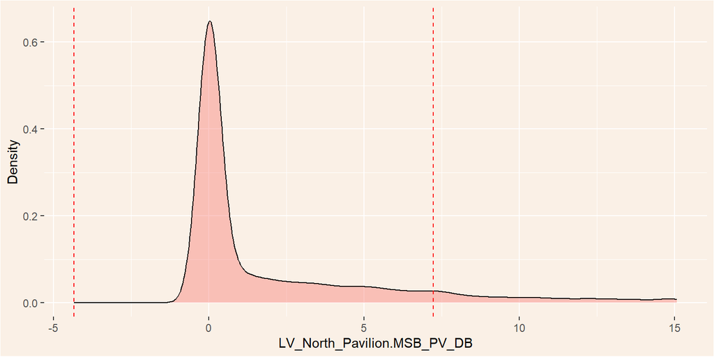

```r
# Step 5. IQR outlier density plot (before -> plot 1)
used_df <- gvoused_df

# Calculate IQR, Q3, and Q1
calc_iqr <- IQR(used_df$observed_values)
q1 <- as.numeric(quantile(used_df$observed_values, probs = 0.25))
q3 <- as.numeric(quantile(used_df$observed_values, probs = 0.75))

# Vertical line for the right and left tails
right_taili <- q3 + 1.5 * calc_iqr
left_taili <- q1 - 1.5 * calc_iqr

# Plotting
ggplot(data=used_df, aes(x=observed_values, fill="purple")) +
  geom_density(adjust=1.5, alpha=.4) +
  geom_vline(xintercept=right_taili, linetype="dashed", color = "red") +
  geom_vline(xintercept=left_taili, linetype="dashed", color = "red") +
  xlab("LV_North_Pavilion.MSB_PV_DB") +
  ylab("Density") +
  theme(panel.background = element_rect(fill = "linen")) +
  theme(plot.background = element_rect(fill = "linen")) +
  theme(legend.position = "none")
```

```r
# Step 6. IQR outlier boxplot (before -> plot 2)
used_df <- gvoused_df

# Plotting
used_df %>%
  ggplot(aes(x = observed_values, y = observed_variables)) +
  geom_boxplot(outlier.color="red") +
  labs(x = "Value",
       y = "Observed Variables") +
  theme(panel.background = element_rect(fill = "linen")) +
  theme(plot.background = element_rect(fill = "linen")) +
  theme(axis.text.y = element_text(angle = 90, vjust = 1, hjust=0.5))
```

[output not shown]

#### **Feature Selection Part (i.e., Server environment)**

**(RShiny App Lines: 1912 - 2078)**

```r
                                  ##### Feature Selection Part #####
## Feature Selection Codes for Filtering and Plot Parts (i.e., Server environment) (RShiny App Lines: 1912 - 2078)

# Step 1. Randomly sampled 10.000 observations from the big dataset (To reduce the expensive running time for the Random Forest and Boruta methods). This is our validation set.

set.seed(8)

gvmini_selection_df <- if (nrow(selection_df)  > 10000) {
  selection_df[sample(nrow(selection_df), 10000), ]
} else {
  selection_df
}
```

```r
# Step 2a. Linear Regression Method

# (In this case, we will use pv_values as a response variable and the remaining variables as an explanatory variable (Use full dataset))

# Fit the model

# Step 2a.1. Set Seed
set.seed(8)

# Step 2a.2. Fitting the model
gvlmMod <- lm(pv_values ~ ., data = selection_df)  # fit lm() model
```

```r
# Step 2a.3. Calculate the variable importance
gvrelImportance <- varImp(gvlmMod, scale = FALSE)  # calculate variable importance scaled to 100
```

[figure not shown]

```r
# Step 2a.4. Visualize variable importance
# Get variable importance from the model fit
gvImpDataRI <- as.data.frame(gvrelImportance) %>%
  rename(VImportance = "Overall") %>%
  arrange(desc(VImportance))
gvImpDataRI$Var_Names <- row.names(gvImpDataRI)

# Plotting
ggplot(gvImpDataRI, aes(x=Var_Names, y=VImportance)) +
  geom_segment( aes(x=Var_Names, xend=Var_Names, y=0, yend=VImportance), color="skyblue") +
  geom_point(color="blue", alpha=0.6) +
  coord_flip() +
  xlab("Variable") +
  ylab("variable Importance") +
  theme(
    legend.position="bottom",
    panel.grid.major.y = element_blank(),
    panel.border = element_blank(),
    axis.ticks.y = element_blank()
  ) +
  theme(panel.background = element_rect(fill = "linen")) +
  theme(plot.background = element_rect(fill = "linen"))
```

```r
# Step 2b. Random Forest Method
# Ref: https://hackernoon.com/random-forest-regression-in-r-code-and-interpretation

# In this case, we will use pv_values as a response variable and the remaining variables as an explanatory variable with the random forest's parameters of 5 and 10 for mtry and ntree, respectively. (Use randomly sampled 10000 observations from the big dataset)

# Step 2b.1. Set Seed
set.seed(8)

# Step 2b.2. Fit the random forest model with mtry = 5 and ntree = 10
gvrf_fit <- randomForest(pv_values ~ ., data=gvmini_selection_df, mtry=5, ntree=10,
                       keep.forest=FALSE, importance=TRUE)
```

```r
gvrf_fit
#
# Call:
#  randomForest(formula = pv_values ~ ., data = gvmini_selection_df,      mtry = 5, ntree = 10, keep.forest = FALSE, importance = TRUE)
#                Type of random forest: regression
#                      Number of trees: 10
# No. of variables tried at each split: 5
#
#           Mean of squared residuals: 91.57082
#                     % Var explained: 87.08
```

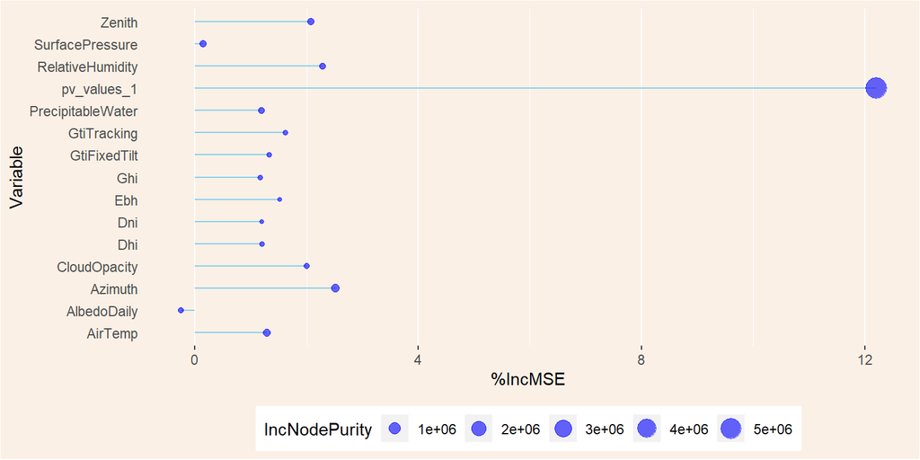

```r
# Step 2b.3. Visualize variable importance
# Get variable importance from the model fit
gvImpData <- as.data.frame(importance(gvrf_fit))
gvImpData$Var_Names <- row.names(gvImpData)

# Plotting
ggplot(gvImpData, aes(x=Var_Names, y=`%IncMSE`)) +
  geom_segment( aes(x=Var_Names, xend=Var_Names, y=0, yend=`%IncMSE`), color="skyblue") +
  geom_point(aes(size = IncNodePurity), color="blue", alpha=0.6) +
  coord_flip() +
  xlab("Variable") +
  theme(
    legend.position="bottom",
    panel.grid.major.y = element_blank(),
    panel.border = element_blank(),
    axis.ticks.y = element_blank()
  ) +
  theme(panel.background = element_rect(fill = "linen")) +
  theme(plot.background = element_rect(fill = "linen"))
```

```r
# Step 2c. MARS Method

# In this case, we will use pv_values as a response variable and the remaining variables as an explanatory variable (Use full dataset)

# Step 2c.1. Set Seed
set.seed(8)

# Step 2c.2. Fitting the model and calculate the variable importance
gvmarsModel <- earth(pv_values ~ ., data=selection_df) # build model
```

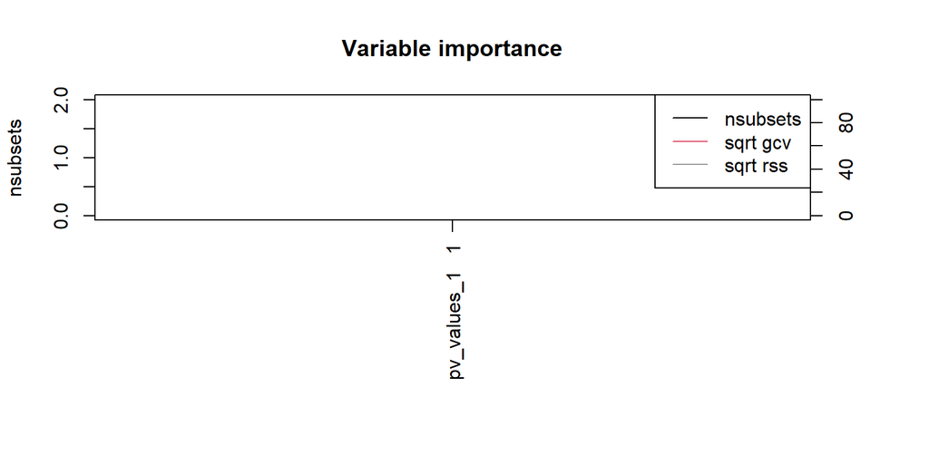

```r
# Step 2c.3. Estimate the variable importance
gvev <- evimp(gvmarsModel) # estimate variable importance

# Step 2c.4. Visualize variable importance
plot(gvev)
```

```r
# Step 2d. Boruta Method

# In this case, we will use pv_values as a response variable and the remaining variables as an explanatory variable. (Use randomly sampled 10000 observations from the big dataset)

# Step 2d.1. Set Seed
set.seed(8)

# Step 2d.2. Fitting the model and calculate the variable importance
gvboruta_output <- Boruta(pv_values ~ ., data=gvmini_selection_df, doTrace=2, maxRuns=25)  # perform Boruta search
```

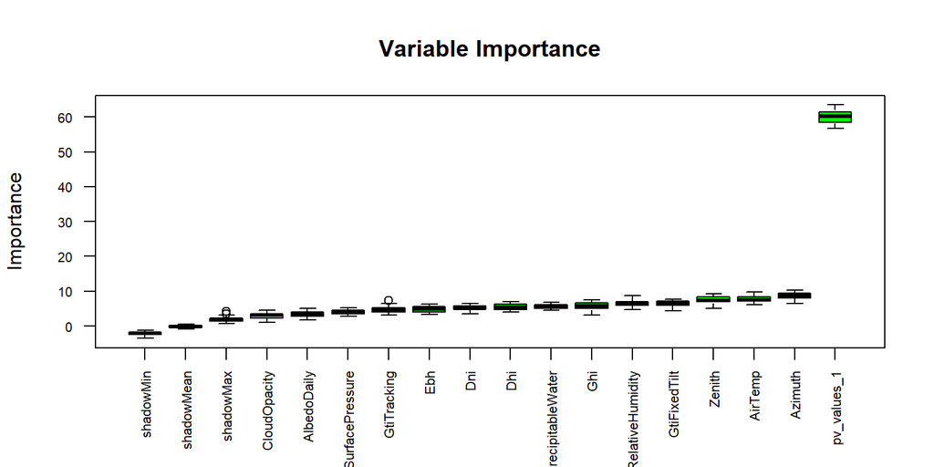

```r
# Step 2d.3. Plotting the variable importance
plot(gvboruta_output, cex.axis=.7, las=2, xlab="", main="Variable Importance")  # plot variable importance
```

#### **Trend Part (i.e., Server environment)**

**(RShiny App Lines: 2081 - 2125)**

```r
                                       ##### Trend Part #####
## Trend Codes for Filtering and Plot Parts (i.e., Server environment) (RShiny App Lines: 2081 - 2125)

# (In this example, we will be using LV_North_Pavilion.MSB_PV_DB from 2020-07-01 to 2021-07-16)

# Step 1. Create trend_df -> the subset of pv dataset after filtered by date and variable
gvtrend_df <- pv %>%
  filter(between(PVdate, as.Date('2020-07-01'), as.Date('2021-07-16'))) %>% # filter Date
  dplyr::select(c(ReadTime, LV_North_Pavilion.MSB_PV_DB)) %>% # filter column
  na.omit() # remove NAs
```

```r
# Step 2. Change the trend_df into time series (ts) object

# Step 2a. Convert ReadTime into datetime data type by using Lubridate package
gvtrenddatetime_df <- gvtrend_df
gvtrenddatetime_df$ReadTime <- dmy_hm(gvtrenddatetime_df$ReadTime)

# Step 2b. Convert dataframe to time series
gvtseries <- read.zoo(gvtrenddatetime_df)

# Step 2c. Convert to ts object
gvtseries_ts <- ts(gvtseries, frequency = 96)
```

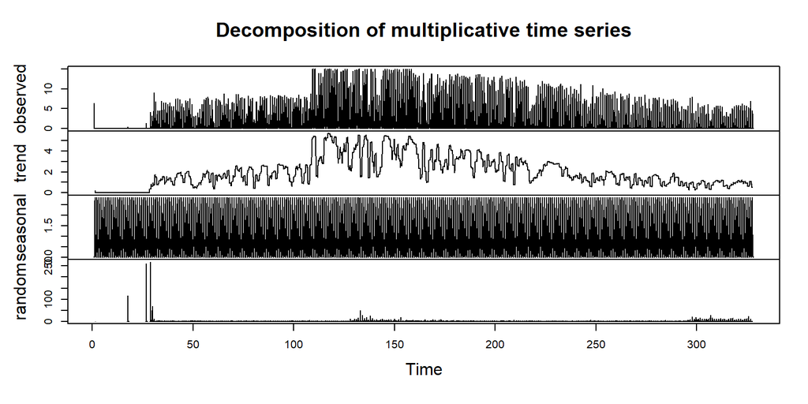

```r
# Step 3. Decompose the trend
gvdecomposed_tseries_ts <- decompose(gvtseries_ts,type='multiplicative')

# Step 4. Plotting
plot(gvdecomposed_tseries_ts)
```

### **Distribution Analysis Codes for Filtering and Plot Parts (i.e., Server environment)**

**(RShiny App Lines: 2158 - 2487)**

This section will cover all the codes in the server environment for the Distribution Page. To simplify the codes’ report, in this example, the inputs for each element in the Distribution Page are as follow:

1. Set LV_North_Pavilion.MSB_PV_DB from 2020-07-01 to 2021-07-16 and all time period in the main filter (i.e., blue gear icon);
2. For the Distribution Plot, the additional filter (i.e., red gear icon) sets the Remove Zero Observation(s) as “Yes”, Remove Negative Observation(s) as “Yes”, Remove Outlier(s) as “Yes, Z-Score Approach”, and Transformation Method as “Raw”.

```r
# Distribution Analysis Codes for Filtering and Plot Parts (i.e., Server environment) (RShiny App Lines: 2158 - 2487)

# (In this example, we will be using LV_North_Pavilion.MSB_PV_DB from 2020-07-01 to 2021-07-16 and all time period)

# Step 1. Create dfiltered_df by filtering observed.variables, Date, and PVtime
dfiltered_df <- pv_data %>%
  filter(observed_variables %in% c("LV_North_Pavilion.MSB_PV_DB")) %>% # filter observed.variables
  filter(between(PVdate, as.Date('2020-07-01'), as.Date('2021-07-16'))) %>% # filter Date
  filter(!(PVtime %in% c(""))) # filter PVtime

# Step 2. Missing Value DF
# Since it is a transformation method, we need to remove the missing values before plotting to avoid errors
rmv_na_df <- dfiltered_df %>%
  # Remove NA(s) / Missing Value(s)
  na.omit()

# (The additional filter (i.e., red gear icon) sets the Remove Zero Observation(s) as "Yes", Remove Negative Observation(s) as "Yes", Remove Outlier(s) as "Yes, Z-Score Approach", and Transformation Method as "Raw".)

rmv_zero_df <- rmv_na_df %>%
  # Remove 0 observation(s)
  filter(observed_values != 0)

# Step 4. Remove Negative Value(s) Option
rmv_negative_df <- rmv_zero_df %>%
  # Remove negative value(s)
  filter(observed_values >= 0)

# Step 5. Remove Outlier(s) Option
temp_df <- rmv_negative_df

# Z-Score Calculation
right_tailz <- mean(temp_df$observed_values) + 3*sd(temp_df$observed_values)
left_tailz <- mean(temp_df$observed_values) - 3*sd(temp_df$observed_values)

# IQR Calculation
# Calculate IQR, Q3, and Q1
calc_iqr <- IQR(temp_df$observed_values)
q1 <- as.numeric(quantile(temp_df$observed_values, probs = 0.25))
q3 <- as.numeric(quantile(temp_df$observed_values, probs = 0.75))

right_taili <- q3 + 1.5 * calc_iqr
left_taili <- q1 - 1.5 * calc_iqr

rmv_outlier_df <- temp_df %>%
  # Remove outlier(s) with Z-Score method as an example
  filter(observed_values < right_tailz & observed_values > left_tailz)

# Step 6. Transformation Method Option
dused_df1 <- rmv_outlier_df %>%
  mutate(square_data = observed_values^2,
         cubic_data = observed_values^3,
         squareroot_data = sqrt(observed_values),
         cuberoot_data = observed_values^(1/3),
         logarithm10 = log10(observed_values),
         logarithmnat = log(observed_values))
```

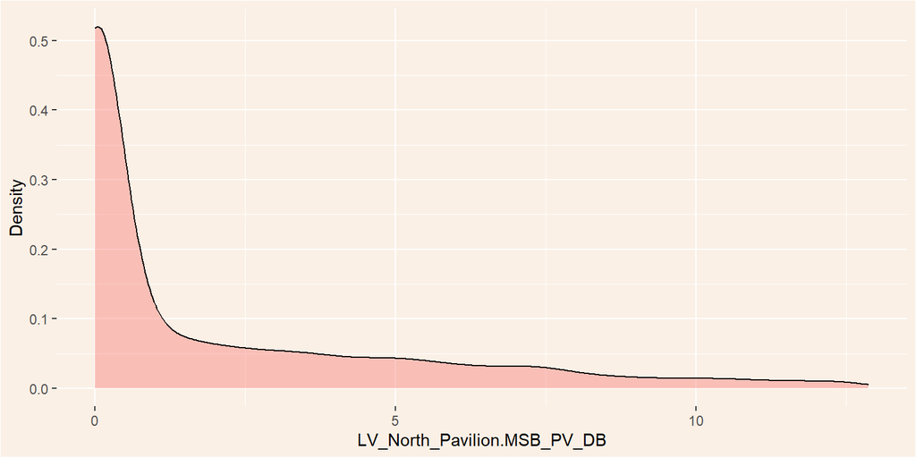

```r
# Step 7. Distribution of Density Plot
ggplot(data=dused_df1, aes(x=observed_values, fill="purple")) +
  geom_density(adjust=1.5, alpha=.4) +
  xlab(as.character("LV_North_Pavilion.MSB_PV_DB")) +
  ylab("Density") +
  theme(panel.background = element_rect(fill = "linen")) +
  theme(plot.background = element_rect(fill = "linen")) +
  theme(legend.position = "none")
```

```r
# Step 8. Distribution Plot's Descriptive Statistics

# Step 8.1. Variable Name
as.character("LV_North_Pavilion.MSB_PV_DB")
# [1] "LV_North_Pavilion.MSB_PV_DB"

# Step 8.2. Number of Observations
nrow(dused_df1)
# [1] 26656

# Step 8.3. Descriptive Statistics
summary(dused_df1$observed_values)
#    Min. 1st Qu.  Median    Mean 3rd Qu.    Max.
#   0.001   0.001   0.125   2.016   3.276  12.865

# Step 8.4. Standard Deviation
round(sd(dused_df1$observed_values), 3)
# [1] 3.054

# Step 8.5. Skewness
round(skewness(dused_df1$observed_values), 3)
# [1] 1.599
```

```r
# Step 9. Negative Values Table
negative_df_step9 <- dfiltered_df %>%
  # Filter negative value(s)
  filter(observed_values < 0) %>%
  dplyr::select(ReadTime, observed_variables, observed_values)

negative_df_step9
# # A tibble: 0 × 3
# # … with 3 variables: ReadTime <chr>, observed_variables <chr>,
# #   observed_values <dbl>
```

```r
# Step 10. Negative Values Table's Descriptive Statistics
negative_df <- dfiltered_df %>%
  # Filter negative value(s)
  filter(observed_values < 0)

# Step 10.1. Variable Name
as.character("LV_North_Pavilion.MSB_PV_DB")
# [1] "LV_North_Pavilion.MSB_PV_DB"

# Step 10.2. Number of Observations
nrow(negative_df)
# [1] 0

# Step 10.3. Descriptive Statistics
summary(negative_df$observed_values)
#    Min. 1st Qu.  Median    Mean 3rd Qu.    Max.
#

# Step 10.4. Standard Deviation
round(sd(negative_df$observed_values), 3)
# [1] NA

# Step 10.5. Skewness
round(skewness(negative_df$observed_values), 3)
# [1] NaN
```

```r
# Step 11. Zero Value Table
zero_df_step11 <- dfiltered_df %>%
  # Filter negative value(s)
  filter(observed_values == 0) %>%
  dplyr::select(ReadTime, observed_variables, observed_values)

zero_df_step11
# # A tibble: 4,123 × 3
#    ReadTime           observed_variables          observed_values
#    <chr>              <chr>                                 <dbl>
#  1 20/7/2020 8:45 PM  LV_North_Pavilion.MSB_PV_DB               0
#  2 20/7/2020 9:00 PM  LV_North_Pavilion.MSB_PV_DB               0
#  3 14/8/2020 9:00 PM  LV_North_Pavilion.MSB_PV_DB               0
#  4 14/8/2020 9:15 PM  LV_North_Pavilion.MSB_PV_DB               0
#  5 14/8/2020 9:30 PM  LV_North_Pavilion.MSB_PV_DB               0
#  6 14/8/2020 9:45 PM  LV_North_Pavilion.MSB_PV_DB               0
#  7 14/8/2020 10:00 PM LV_North_Pavilion.MSB_PV_DB               0
#  8 14/8/2020 10:15 PM LV_North_Pavilion.MSB_PV_DB               0
#  9 14/8/2020 10:30 PM LV_North_Pavilion.MSB_PV_DB               0
# 10 14/8/2020 10:45 PM LV_North_Pavilion.MSB_PV_DB               0
# # … with 4,113 more rows
```

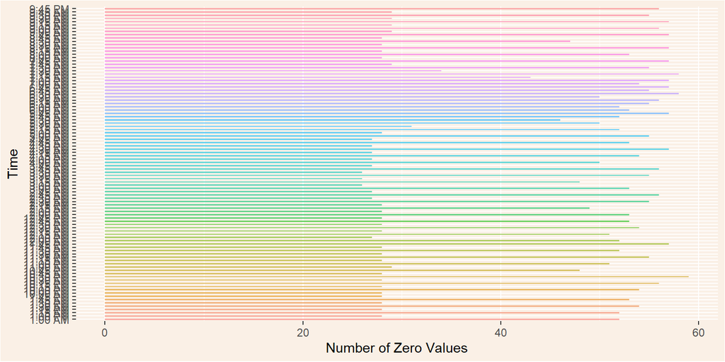

```r
# Step 12. Zero Value Count Plot

# Step 12.1. Create Wider format dataset after filtering only zero values
zero_df_step12 <- dfiltered_df %>%
  filter(observed_values == 0) %>%
  dplyr::select(PVtime, observed_values) %>%
  count(PVtime, sort = TRUE) %>%
  rename(zero_count = n)

# Step 12.2. Plotting
zero_df_step12 %>%
  ggplot(aes(x = zero_count, y = PVtime, fill = as.factor(PVtime),
             text=paste("Time: ", PVtime,
                            "\nZero Value: ", zero_count))) + # Text=paste() only for Plotly
  geom_bar(stat="identity", alpha=.6, width=.4) +
  xlab("Number of Zero Values") +
  ylab("Time") +
  theme(legend.position="none") +
  theme(panel.background = element_rect(fill = "linen")) +
  theme(plot.background = element_rect(fill = "linen"))
```

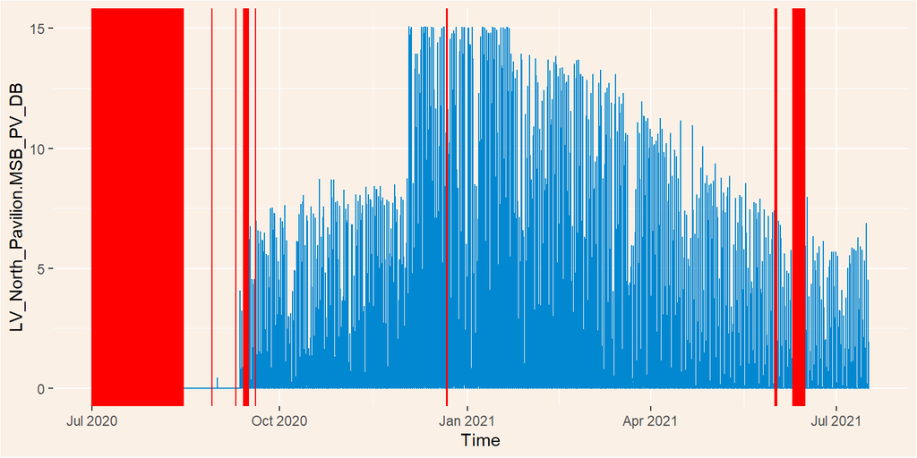

```r
# Step 13. Time Series Plot

# Step 13.a. Create datetime_df
# Step 13.1. Convert ReadTime into datetime data type by using Lubridate package
datetime_df <- dfiltered_df
datetime_df$ReadTime <- dmy_hm(datetime_df$ReadTime)

# Step 13.2. Create dummy if NA = Missing, and present = Present
datetime_df$missing_dummy <- ifelse(is.na(datetime_df$observed_values), "Missing", "Present")

# Step 13.b. Plotting (Without Interactive Feature)
ggplot(datetime_df, aes(x = ReadTime, y = observed_values, group = 1)) +
      geom_line(color="#0288d1") +
      geom_vline(xintercept = datetime_df$ReadTime[datetime_df$missing_dummy == "Missing"], color = "red") +
      xlab("Time") +
      ylab("LV_North_Pavilion.MSB_PV_DB") +
      scale_color_discrete(name = "Status") +
      theme(panel.background = element_rect(fill = "linen")) +
      theme(plot.background = element_rect(fill = "linen"))
```

```r
# Step 13.c. Plotting (With Interactive Feature)
p <- ggplot(datetime_df, aes(x = ReadTime, y = observed_values, group = 1,
                             text=paste("Date: ", PVdate,
                                        "\nTime: ", PVtime,
                                        "\nValue: ", observed_values,
                                        "\nStatus: ", missing_dummy))) +
  geom_line(color="#0288d1") +
  xlab("Time") +
  ylab("LV_North_Pavilion.MSB_PV_DB") +
  scale_color_discrete(name = "Status") +
  theme(panel.background = element_rect(fill = "linen")) +
  theme(plot.background = element_rect(fill = "linen"))

ggplotly(p, tooltip = "text")
```

[output not shown]

### **Missing Value Codes for Filtering and Plot Parts (i.e., Server environment)**

**(RShiny App Lines: 2489 - 2744)**

This section will cover all the codes in the server environment for the Missing Value Page. To simplify the codes’ report, in this example, the inputs for each element in the Missing Value Page are as follow:

1. Set LV_Sport_01.PVDB.DB.A, LV_Sport_01.PVDB.DB.B, LV_Sport_01.PVDB.MSSB, LV_North_Pavilion.MSB_PV_DB, and LV_Robert_Blackwood_Hall_2.Main_Solar_Supply from 2020-07-01 to 2021-07-16 and all time period in the main filter (i.e., blue gear icon);
2. For the UpsetR Plot, the additional filter (i.e., red gear icon) sets Observed Variables as “LV_Sport_01.PVDB.DB.A, LV_Sport_01.PVDB.DB.B, LV_Sport_01.PVDB.MSSB, LV_North_Pavilion.MSB_PV_DB, and LV_Robert_Blackwood_Hall_2.Main_Solar_Supply”;
3. For the Missingness across Factors Plot, the additional filter (i.e., red gear icon) sets Categorical Variable (Factor) as “AMorPM”.

```r
## Missing Value Codes for Filtering and Plot Parts (i.e., Server environment)
# (RShiny App Lines: 2489 - 2744)

# (In this example we will be using LV_Sport_01.PVDB.DB.A, LV_Sport_01.PVDB.DB.B, LV_Sport_01.PVDB.MSSB, LV_North_Pavilion.MSB_PV_DB, and LV_Robert_Blackwood_Hall_2.Main_Solar_Supply from 2020-07-01 to 2021-07-16 and all time period)

# Step 1. Create filtered_df by filtering observed.variables, Date, and PVtime
filtered_df <- pv_data %>%
  filter(observed_variables %in% c("LV_Sport_01.PVDB.DB.A",
                                   "LV_Sport_01.PVDB.DB.B",
                                   "LV_Sport_01.PVDB.MSSB",
                                   "LV_North_Pavilion.MSB_PV_DB",
                                   "LV_Robert_Blackwood_Hall_2.Main_Solar_Supply")) %>% # filter observed.variables
  filter(between(PVdate, as.Date('2020-07-01'), as.Date('2021-07-16'))) %>% # filter Date
  filter(!(PVtime %in% c(""))) # filter PVtime

# Step 2. Creating Missing Value Table

# Step 2.1. Reformat filtered_df from long to wide format to calculate the number of missing rows easily
filtered_df_wider <- filtered_df %>%
  # Change from long into wide format
  pivot_wider(names_from = observed_variables, values_from = observed_values) %>%
  # Deselect helper variables
  dplyr::select(!c(PVdate, dayofmonth, month, year, timefactor, AMorPM, PVtime))

# Step 2.2. Creating Missing Value Dataframe
missing_df <- as_tibble(lapply(filtered_df_wider, function(x) sum(is.na(x)))) %>%
      gather(key = "variable_name", value = "missing_count") %>%
      # Calculate the total missing values category in the dataset
      bind_rows(summarise(.,
                          across(where(is.numeric), sum),
                          across(where(is.character), ~'Total')))

# Step 2.3. Send the output of missing_df in step 2.2. above to the frontend after filter out the
# Total category that we created previously
missing_df %>%
  # Filter out the Total category that we created previously
  filter(variable_name != "Total")
# # A tibble: 6 × 2
#   variable_name                                missing_count
#   <chr>                                                <int>
# 1 ReadTime                                                 0
# 2 LV_Sport_01.PVDB.DB.A                                 1393
# 3 LV_Sport_01.PVDB.DB.B                                16789
# 4 LV_Sport_01.PVDB.MSSB                                 3675
# 5 LV_North_Pavilion.MSB_PV_DB                           5167
# 6 LV_Robert_Blackwood_Hall_2.Main_Solar_Supply            22
```

```r
# Step 3. Missing Value Table's Descriptive Statistics

# Step 3.1. Create filtered_df_nona to count problematic row (i.e., there is an existence of missing values in one or more columns)
filtered_df_nona <- na.omit(filtered_df_wider) # Remove missing value in the filtered_df_wider dataframe to find # of rows that is fine (i.e., no missing value)

# Step 3.2. Number of observations
nrow(filtered_df_wider)
# [1] 36571

# Step 3.3. Total problematic rows
nrow(filtered_df_wider) - nrow(filtered_df_nona)
# [1] 24277

# Step 3.4. Proportion of problematic rows
x <- nrow(filtered_df_wider)
y <- nrow(filtered_df_wider) - nrow(filtered_df_nona)
z <- round((y / x) * 100, 2)

# Concatenate string
paste(as.character(z), "%", sep = "")
# [1] "66.38%"

# Step 3.5. Number of cells
nrow(filtered_df)
# [1] 182855

# Step 3.6. Total missing by the number of cells
as.integer(missing_df[missing_df$variable_name == "Total", "missing_count"])
# [1] 27046

# Step 3.7. Proportion of missing by the number of cells
x <- round(as.integer(missing_df[missing_df$variable_name == "Total", "missing_count"]) / nrow(filtered_df) * 100, 2)

# Concatenate string
paste(as.character(x), "%", sep = "")
# [1] "14.79%"
```

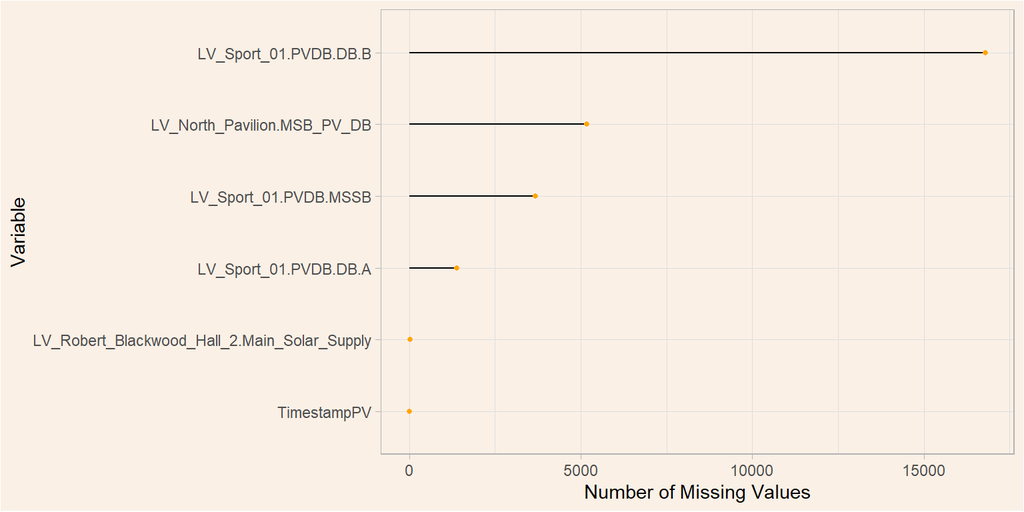

```r
# Step 4. Missing Value Plot 1 (Count Plot)

# Filter out Total category in the variable_name variable
missing_df <- missing_df %>%
  filter(variable_name != "Total")

missing_df %>%
      # Order by missing_count
  arrange(missing_count) %>%
  mutate(variable_name=factor(variable_name, levels=variable_name)) %>%
  ggplot(aes(x=variable_name, y=missing_count,
             # Text only for plotly
             text=paste("Building Name: ", variable_name,
                        "\nMissing Value: ", missing_count))) +
  geom_segment(aes(x=variable_name, xend=variable_name, y=0, yend=missing_count), color="black") +
  geom_point(color="orange", size=1, alpha=1) +
  theme_light() +
  coord_flip() +
  xlab("Variable") +
  ylab("Number of Missing Values") +
  theme(panel.background = element_rect(fill = "linen")) +
  theme(plot.background = element_rect(fill = "linen"))
```

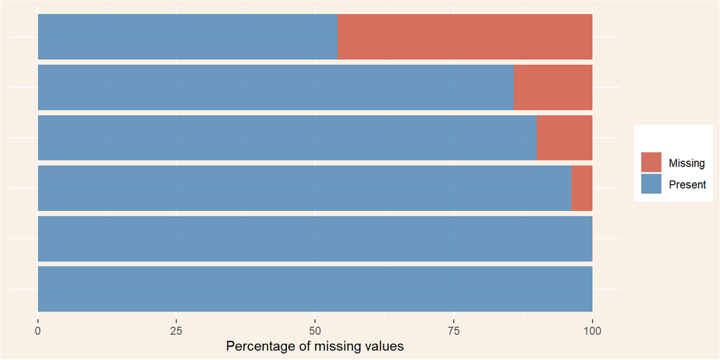

```r
# Step 5. Missing Value Plot 2 (Proportion Plot)

# Create new dataframe that include the calculation of proportion of the missing values for each variable
newdata <- missing_df %>%
  rename(Missing = missing_count) %>%
  filter(variable_name != "Total") %>%
  mutate(Present = nrow(filtered_df_wider) - Missing) %>%
  pivot_longer(cols = !c("variable_name"),
               names_to = "isna",
               values_to = "total_count") %>%
  mutate(pct = total_count / nrow(filtered_df_wider) * 100)

# Sort from highest to lowest
levels <-
  (newdata  %>% filter(isna == "Missing") %>% arrange(pct))$variable_name

# Plotting
newdata %>%
  ggplot(aes(x = reorder(variable_name, pct),
             y = pct, fill=isna,
             text=paste("Building Name: ", variable_name,
                        "\nStatus: ", isna,
                        "\nCount: ", total_count,
                        "\nPercentage: ", paste(round(pct, 2), "%", sep = "")))) +
  geom_bar(stat = 'identity', alpha=0.8) +
  scale_x_discrete(limits = levels) +
  scale_fill_manual(name = "",
                    values = c('tomato3', 'steelblue')) +
  coord_flip() +
  labs(x ='Variable',
       y = "Percentage of missing values") +
  theme(axis.title.y=element_blank(),
        axis.text.y=element_blank(),
        axis.ticks.y=element_blank()) +
  theme(panel.background = element_rect(fill = "linen")) +
  theme(plot.background = element_rect(fill = "linen"))
```

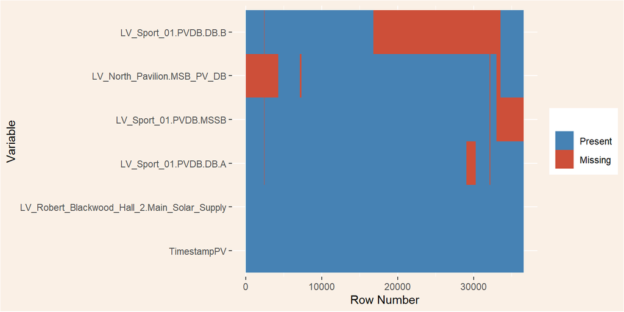

```r
# Step 6. Missing Value Plot 3 (Stacked Bar-Chart / Where the Missing Plot)

# Create new dataframe that include the calculation of proportion of the missing values for each variable
newdata <- missing_df %>%
  rename(Missing = missing_count) %>%
  filter(variable_name != "Total") %>%
  mutate(Present = nrow(filtered_df_wider) - Missing) %>%
  pivot_longer(cols = !c("variable_name"),
               names_to = "isna",
               values_to = "total_count") %>%
  mutate(pct = total_count / nrow(filtered_df_wider) * 100)

# Sort from highest to lowest
levels <-
  (newdata  %>% filter(isna == "Missing") %>% arrange(pct))$variable_name

# Plotting
filtered_df_wider %>%
  mutate(id = row_number()) %>%
  gather(-id, key = "key", value = "val") %>%
  mutate(isna = is.na(val)) %>%
  ggplot(aes(x = key, y = id, fill = isna)) +
  geom_tile() +
  scale_fill_manual(name = "",
                    values = c('steelblue', 'tomato3'),
                    labels = c("Present", "Missing"))  +
  scale_x_discrete(limits = levels) +
  labs(x = "Variable",
       y = "Row Number") +
  coord_flip() +
  theme(panel.background = element_rect(fill = "linen")) +
  theme(plot.background = element_rect(fill = "linen"))
```

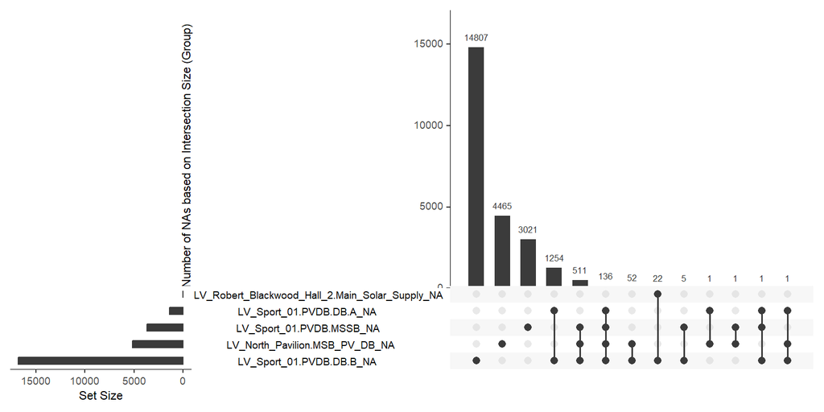

```r
# Step 7. Missing Value Plot 4 (Exploring patterns with UpSetR)

newdata <- filtered_df %>%
  filter(observed_variables %in% c("LV_Sport_01.PVDB.DB.A",
                                   "LV_Sport_01.PVDB.DB.B",
                                   "LV_Sport_01.PVDB.MSSB",
                                   "LV_North_Pavilion.MSB_PV_DB",
                                   "LV_Robert_Blackwood_Hall_2.Main_Solar_Supply")) %>%
  # Change into pivot wider
  pivot_wider(names_from = observed_variables, values_from = observed_values) %>%
  dplyr::select(!c(PVdate, dayofmonth, month, year, timefactor, AMorPM, PVtime))

gg_miss_upset(newdata, nsets = 5,
              mainbar.y.label="Number of NAs based on Intersection Size (Group)")
```

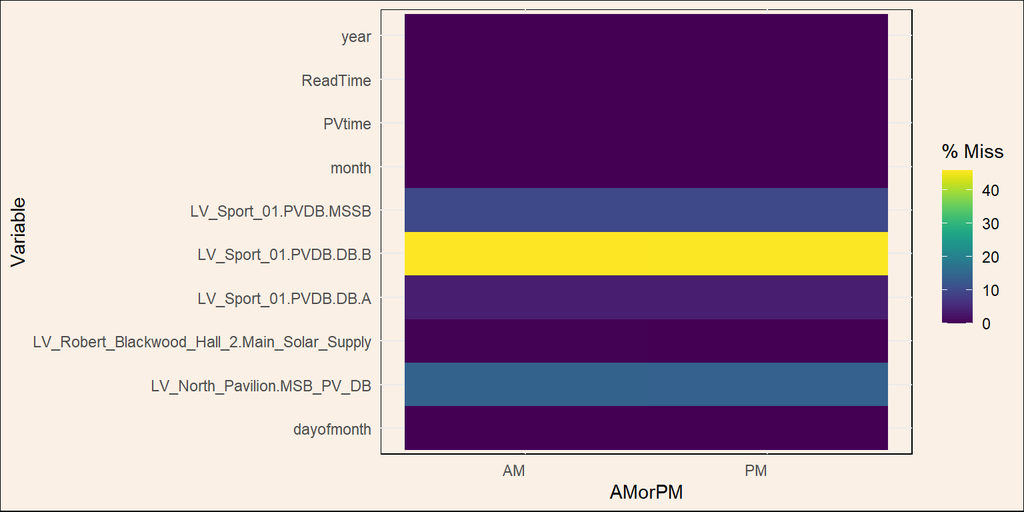

```r
# Step 8. Missing Value Plot 5 (Missingness across Factors Plot)

newdata <- filtered_df %>%
  pivot_wider(names_from = observed_variables, values_from = observed_values) %>%
  dplyr::select(!c(PVdate, timefactor))

gg_miss_fct(x = newdata, fct = AMorPM) + # In this case, we will use AMorPM factor
  theme(panel.background = element_rect(fill = "linen")) +
  theme(plot.background = element_rect(fill = "linen")) +
  theme(axis.text.x = element_text(angle = 0)) +
  ylab("Variable")
```

### **Outlier Codes for Filtering and Plot Parts (i.e., Server environment)**

**(RShiny App Lines: 2746 - 3072)**

This section will cover all the codes in the server environment for the Outlier Page. To simplify the codes’ report, in this example, the inputs for each element in the Outlier Page are as follow:

1. Set LV_North_Pavilion.MSB_PV_DB from 2020-07-01 to 2021-07-16 and all time period in the main filter (i.e., blue gear icon);

```r
# Outlier Codes for Filtering and Plot Parts (i.e., Server environment)
# (RShiny App Lines: 2746 - 3072)

# (In this example, we will be using LV_North_Pavilion.MSB_PV_DB from 2020-07-01 to 2021-07-16 and all time period)

# Step 1. Create ofiltered_df by filtering observed.variables, Date, and PVtime
ofiltered_df <- pv_data %>%
  filter(observed_variables %in% c("LV_North_Pavilion.MSB_PV_DB")) %>% # filter observed.variables
  filter(between(PVdate, as.Date('2020-07-01'), as.Date('2021-07-16'))) %>% # filter Date
  filter(!(PVtime %in% c(""))) # filter PVtime

# Step 2. Create oused_df dataframe for plotting histograms and boxplots (after removing NAs)
oused_df <- ofiltered_df %>%
  na.omit()
```

#### **Z-Score Approach**

```r
                                      ##### Z-Score Approach #####

# Step 3. Interactive table description (Outlier -> Z-Score Approach)
right_tailz <- mean(oused_df$observed_values) + 3*sd(oused_df$observed_values)
left_tailz <- mean(oused_df$observed_values) - 3*sd(oused_df$observed_values)

oused_df %>%
  filter(observed_values > right_tailz | observed_values < left_tailz) %>%
  dplyr::select(ReadTime, observed_variables, observed_values)
# # A tibble: 844 × 3
#    ReadTime           observed_variables          observed_values
#    <chr>              <chr>                                 <dbl>
#  1 3/12/2020 10:15 AM LV_North_Pavilion.MSB_PV_DB            12.6
#  2 3/12/2020 10:30 AM LV_North_Pavilion.MSB_PV_DB            13.5
#  3 3/12/2020 10:45 AM LV_North_Pavilion.MSB_PV_DB            14.2
#  4 3/12/2020 11:00 AM LV_North_Pavilion.MSB_PV_DB            14.6
#  5 3/12/2020 11:15 AM LV_North_Pavilion.MSB_PV_DB            15.0
#  6 3/12/2020 11:30 AM LV_North_Pavilion.MSB_PV_DB            15.0
#  7 3/12/2020 11:45 AM LV_North_Pavilion.MSB_PV_DB            15.0
#  8 3/12/2020 12:00 PM LV_North_Pavilion.MSB_PV_DB            15.0
#  9 3/12/2020 12:15 PM LV_North_Pavilion.MSB_PV_DB            15.1
# 10 3/12/2020 12:30 PM LV_North_Pavilion.MSB_PV_DB            15.0
# # … with 834 more rows
```

```r
# Step 4. Z-Score Approach Table's Descriptive Statistics

# Step 4.1. Variable Name
as.character("LV_North_Pavilion.MSB_PV_DB")
# [1] "LV_North_Pavilion.MSB_PV_DB"

# Step 4.2. Descriptive Statistics
summary(ofiltered_df$observed_values)
#    Min. 1st Qu.  Median    Mean 3rd Qu.    Max.    NA's
#   0.000   0.001   0.002   1.993   2.890  15.071    5167

# Step 4.3. Standard Deviation
round(sd(oused_df$observed_values), 3)
# [1] 3.375

# Step 4.4. Skewness before removing outliers
round(skewness(oused_df$observed_values), 3)
# [1] 1.933

# Step 4.5. Upper Limit: mean + 3 * stdev
round(mean(oused_df$observed_values) + 3*sd(oused_df$observed_values), 3)
# [1] 12.117

# Step 4.6. Lower Limit: mean - 3 * stdev
round(mean(oused_df$observed_values) - 3*sd(oused_df$observed_values), 3)
# [1] -8.132
```

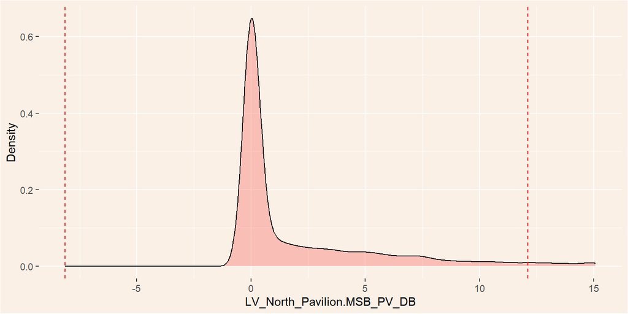

```r
# Step 5. Z-Score outlier density plot (before -> plot 1)
used_df <- oused_df

# Vertical line for the right and left tails
right_tailz <- mean(used_df$observed_values) + 3*sd(used_df$observed_values)
left_tailz <- mean(used_df$observed_values) - 3*sd(used_df$observed_values)

# Plotting
ggplot(data=used_df, aes(x=observed_values, fill="purple")) +
  geom_density(adjust=1.5, alpha=.4) +
  geom_vline(xintercept=right_tailz, linetype="dashed", color = "red") +
  geom_vline(xintercept=left_tailz, linetype="dashed", color = "red") +
  xlab("LV_North_Pavilion.MSB_PV_DB") +
  ylab("Density") +
  theme(panel.background = element_rect(fill = "linen")) +
  theme(plot.background = element_rect(fill = "linen")) +
  theme(legend.position = "none")
```

```r
# Step 6. Z-Score outlier boxplot (before -> plot 2)
used_df <- oused_df

# Plotting
used_df %>%
  ggplot(aes(x = observed_values, y = observed_variables)) +
  geom_boxplot(outlier.color="red") +
  labs(x = "Value",
       y = "Observed Variables") +
  theme(panel.background = element_rect(fill = "linen")) +
  theme(plot.background = element_rect(fill = "linen")) +
  theme(axis.text.y = element_text(angle = 90, vjust = 1, hjust=0.5))
```

[output not shown]

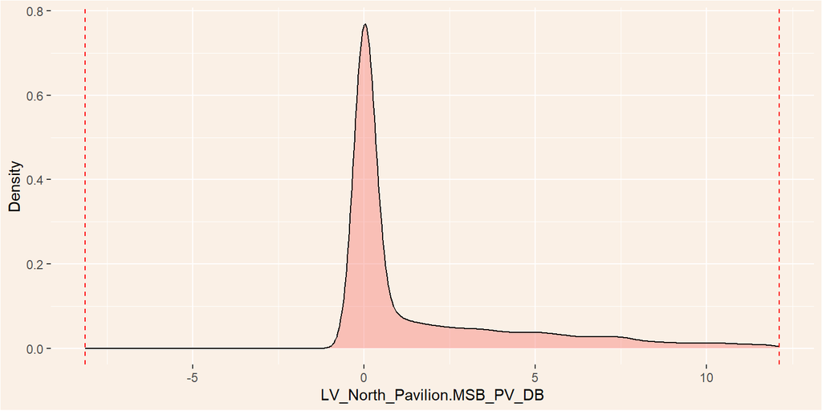

```r
# Step 7. Z-Score outlier density plot (after -> plot 3)
used_df <- oused_df

# Vertical line for the right and left tails
right_tailz <- mean(used_df$observed_values) + 3*sd(used_df$observed_values)
left_tailz <- mean(used_df$observed_values) - 3*sd(used_df$observed_values)

# Plotting
used_df %>%
  filter(observed_values < right_tailz & observed_values > left_tailz) %>%
  ggplot(aes(x=observed_values, fill="purple")) +
  geom_density(adjust=1.5, alpha=.4) +
  geom_vline(xintercept=right_tailz, linetype="dashed", color = "red") +
  geom_vline(xintercept=left_tailz, linetype="dashed", color = "red") +
  xlab("LV_North_Pavilion.MSB_PV_DB") +
  ylab("Density") +
  theme(panel.background = element_rect(fill = "linen")) +
  theme(plot.background = element_rect(fill = "linen")) +
  theme(legend.position = "none")
```

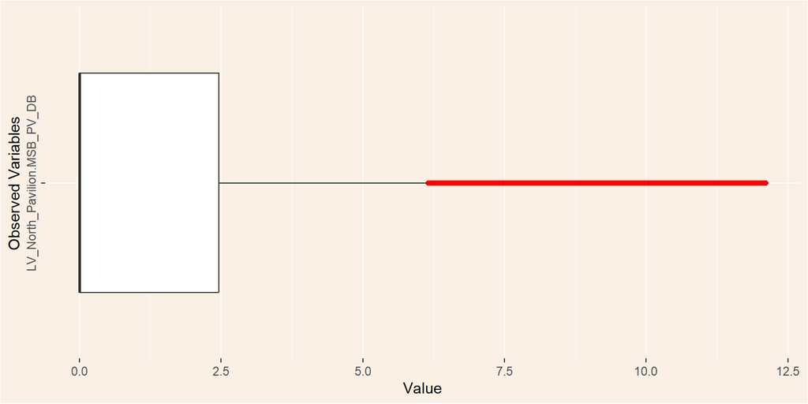

```r
# Step 8. Z-Score outlier boxplot (after -> plot 4)
used_df <- oused_df

# Vertical line for the right and left tails
right_tailz <- mean(used_df$observed_values) + 3*sd(used_df$observed_values)
left_tailz <- mean(used_df$observed_values) - 3*sd(used_df$observed_values)

# Plotting
used_df %>%
  filter(observed_values < right_tailz & observed_values > left_tailz) %>%
  ggplot(aes(x = observed_values, y = observed_variables)) +
  geom_boxplot(outlier.color="red") +
  labs(x = "Value",
       y = "Observed Variables") +
  theme(panel.background = element_rect(fill = "linen")) +
  theme(plot.background = element_rect(fill = "linen")) +
  theme(axis.text.y = element_text(angle = 90, vjust = 1, hjust=0.5))
```

#### **IQR Approach**

```r
                                      ##### IQR Approach #####

# Step 3. Interactive table description (Outlier -> IQR Approach)
# Calculate IQR, Q3, and Q1
calc_iqr <- IQR(oused_df$observed_values)
q1 <- as.numeric(quantile(oused_df$observed_values, probs = 0.25))
q3 <- as.numeric(quantile(oused_df$observed_values, probs = 0.75))

right_taili <- q3 + 1.5 * calc_iqr
left_taili <- q1 - 1.5 * calc_iqr

oused_df %>%
  filter(observed_values > right_taili | observed_values < left_taili) %>%
  dplyr::select(ReadTime, observed_variables, observed_values)
# # A tibble: 3,024 × 3
#    ReadTime            observed_variables          observed_values
#    <chr>               <chr>                                 <dbl>
#  1 15/9/2020 3:00 PM   LV_North_Pavilion.MSB_PV_DB            9.03
#  2 15/9/2020 3:45 PM   LV_North_Pavilion.MSB_PV_DB            7.28
#  3 26/9/2020 1:15 PM   LV_North_Pavilion.MSB_PV_DB            7.50
#  4 27/9/2020 1:00 PM   LV_North_Pavilion.MSB_PV_DB            7.26
#  5 27/9/2020 1:15 PM   LV_North_Pavilion.MSB_PV_DB            7.54
#  6 28/9/2020 11:30 AM  LV_North_Pavilion.MSB_PV_DB            7.31
#  7 3/10/2020 12:45 PM  LV_North_Pavilion.MSB_PV_DB            7.64
#  8 10/10/2020 1:30 PM  LV_North_Pavilion.MSB_PV_DB            7.27
#  9 11/10/2020 12:15 PM LV_North_Pavilion.MSB_PV_DB            7.69
# 10 11/10/2020 1:30 PM  LV_North_Pavilion.MSB_PV_DB            7.43
# # … with 3,014 more rows
```

```r
# Step 4. IQR Approach Table's Descriptive Statistics

# Step 4.1. Variable Name
as.character("LV_North_Pavilion.MSB_PV_DB")
# [1] "LV_North_Pavilion.MSB_PV_DB"

# Step 4.2. Descriptive Statistics
summary(ofiltered_df$observed_values)
#    Min. 1st Qu.  Median    Mean 3rd Qu.    Max.    NA's
#   0.000   0.001   0.002   1.993   2.890  15.071    5167

# Step 4.3. Inter-Quartile Range (IQR)
round(IQR(oused_df$observed_values), 3)
# [1] 2.889

# Step 4.4. Skewness before removing outliers
round(skewness(oused_df$observed_values), 3)
# [1] 1.933

# Step 4.5. Upper Limit: Q3 + 1.5 * IQR
# Calculate IQR, and Q3
calc_iqr <- IQR(oused_df$observed_values)
q3 <- as.numeric(quantile(oused_df$observed_values, probs = 0.75))

round(q3 + 1.5 * calc_iqr, 3)
# [1] 7.224

# Step 4.6. Lower Limit: Q1 - 1.5 * IQR
# Calculate IQR and Q1
calc_iqr <- IQR(oused_df$observed_values)
q1 <- as.numeric(quantile(oused_df$observed_values, probs = 0.25))

round(q1 - 1.5 * calc_iqr, 3)
# [1] -4.333
```

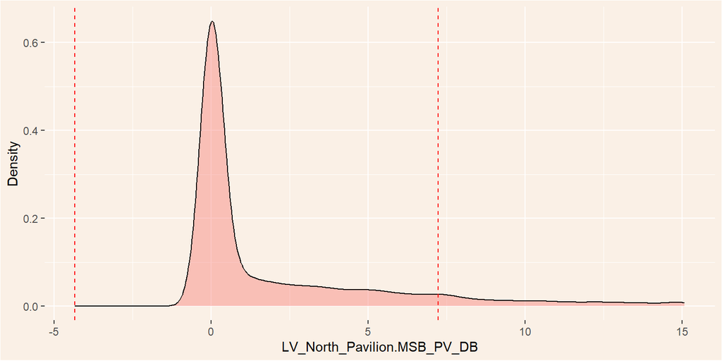

```r
# Step 5. IQR outlier density plot (before -> plot 1)
used_df <- oused_df

# Calculate IQR, Q3, and Q1
calc_iqr <- IQR(used_df$observed_values)
q1 <- as.numeric(quantile(used_df$observed_values, probs = 0.25))
q3 <- as.numeric(quantile(used_df$observed_values, probs = 0.75))

# Vertical line for the right and left tails
right_taili <- q3 + 1.5 * calc_iqr
left_taili <- q1 - 1.5 * calc_iqr

# Plotting
ggplot(data=used_df, aes(x=observed_values, fill="purple")) +
  geom_density(adjust=1.5, alpha=.4) +
  geom_vline(xintercept=right_taili, linetype="dashed", color = "red") +
  geom_vline(xintercept=left_taili, linetype="dashed", color = "red") +
  xlab("LV_North_Pavilion.MSB_PV_DB") +
  ylab("Density") +
  theme(panel.background = element_rect(fill = "linen")) +
  theme(plot.background = element_rect(fill = "linen")) +
  theme(legend.position = "none")
```

```r
# Step 6. IQR outlier boxplot (before -> plot 2)
used_df <- oused_df

# Plotting
used_df %>%
  ggplot(aes(x = observed_values, y = observed_variables)) +
  geom_boxplot(outlier.color="red") +
  labs(x = "Value",
       y = "Observed Variables") +
  theme(panel.background = element_rect(fill = "linen")) +
  theme(plot.background = element_rect(fill = "linen")) +
  theme(axis.text.y = element_text(angle = 90, vjust = 1, hjust=0.5))
```

[output not shown]

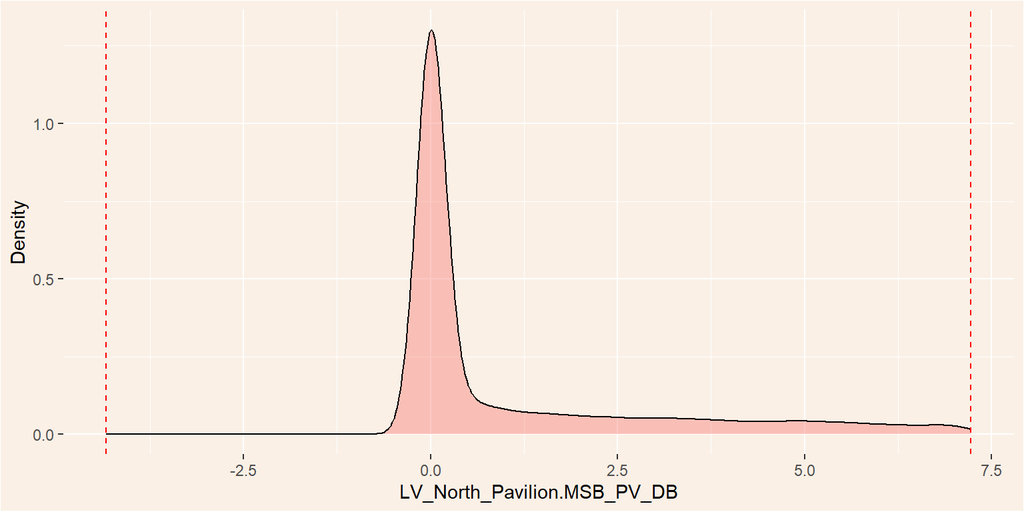

```r
# Step 7. IQR outlier density plot (after -> plot 3)
used_df <- oused_df

# Calculate IQR, Q3, and Q1
calc_iqr <- IQR(used_df$observed_values)
q1 <- as.numeric(quantile(used_df$observed_values, probs = 0.25))
q3 <- as.numeric(quantile(used_df$observed_values, probs = 0.75))

# Vertical line for the right and left tails
right_taili <- q3 + 1.5 * calc_iqr
left_taili <- q1 - 1.5 * calc_iqr

# Plotting
used_df %>%
  filter(observed_values < right_taili & observed_values > left_taili) %>%
  ggplot(aes(x=observed_values, fill="purple")) +
  geom_density(adjust=1.5, alpha=.4) +
  geom_vline(xintercept=right_taili, linetype="dashed", color = "red") +
  geom_vline(xintercept=left_taili, linetype="dashed", color = "red") +
  xlab("LV_North_Pavilion.MSB_PV_DB") +
  ylab("Density") +
  theme(panel.background = element_rect(fill = "linen")) +
  theme(plot.background = element_rect(fill = "linen")) +
  theme(legend.position = "none")
```

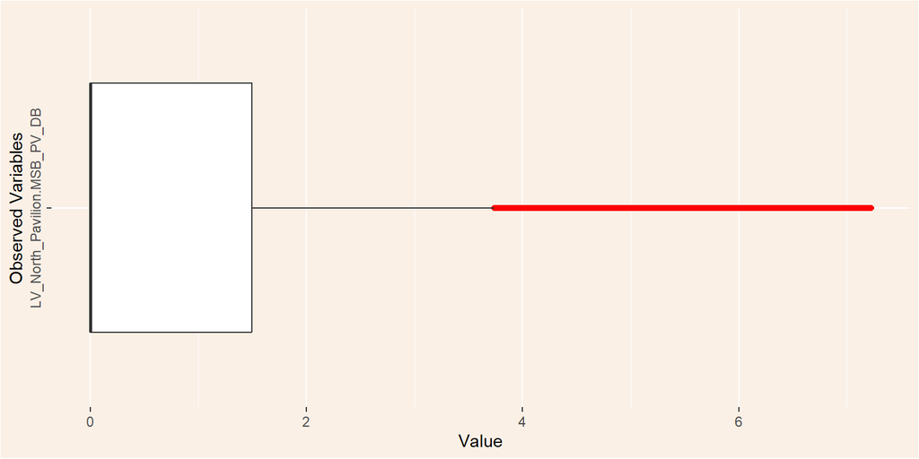

```r
# Step 8. Z-Score outlier boxplot (after -> plot 4)
used_df <- oused_df

# Calculate IQR, Q3, and Q1
calc_iqr <- IQR(used_df$observed_values)
q1 <- as.numeric(quantile(used_df$observed_values, probs = 0.25))
q3 <- as.numeric(quantile(used_df$observed_values, probs = 0.75))

# Vertical line for the right and left tails
right_taili <- q3 + 1.5 * calc_iqr
left_taili <- q1 - 1.5 * calc_iqr

# Plotting
used_df %>%
  filter(observed_values < right_taili & observed_values > left_taili) %>%
  ggplot(aes(x = observed_values, y = observed_variables)) +
  geom_boxplot(outlier.color="red") +
  labs(x = "Value",
       y = "Observed Variables") +
  theme(panel.background = element_rect(fill = "linen")) +
  theme(plot.background = element_rect(fill = "linen")) +
  theme(axis.text.y = element_text(angle = 90, vjust = 1, hjust=0.5))
```

### **Feature Selection Codes for Filtering and Plot Parts (i.e., Server environment)**

**(RShiny App Lines: 3074 - 3384)**

This section will cover all the codes in the server environment for the Feature Selection Page. To simplify the codes’ report, in this example, the inputs for each element in the Feature Selection Page are as follow:

1. Set pv_values as a response variable and the remaining variables as an explanatory variable (i.e., use full dataset) in the main filter (i.e., blue gear icon);
2. For the Random Forest and Boruta methods, the app will use randomly sampled 10.000 observations from the big dataset (to reduce the expensive running time for the Random Forest and Boruta methods). This is our validation set;
3. Furthermore, in the Random Forest method, the additional filter (i.e., red gear icon) sets the random forest’s parameters of 5 and 10 for mtry and ntree, respectively.

```r
## Feature Selection
# (RShiny App Lines: 3074 - 3384)

# Step 1. Randomly sampled 10.000 observations from the big dataset (To reduce the expensive running time for the Random Forest and Boruta methods). This is our validation set.

set.seed(8)

mini_selection_df <- if (nrow(selection_df)  > 10000) {
  selection_df[sample(nrow(selection_df), 10000), ]
} else {
  selection_df
}
```

```r
# Step 2a. variable Importance Method

# In this case, we will use pv_values as a response variable and the remaining variables as an explanatory variable (Use full dataset)

# Fit the model

# Step 2a.1. Set Seed
set.seed(8)

# Step 2a.2. Fitting the model
lmMod <- lm(pv_values ~ ., data = selection_df)  # fit lm() model

# Step 2a.3. Print the fitted linear model
lmMod
#
# Call:
# lm(formula = pv_values ~ ., data = selection_df)
#
# Coefficients:
#                                               (Intercept)
#                                                 8.918e+00
#                                               pv_values_1
#                                                 9.702e-01
#                                                    timeTS
#                                                 1.355e-05
#                                                dayofmonth
#                                                 3.370e-04
#                                                     month
#                                                 5.623e-04
#                                                      year
#                                                -4.840e-03
#                                                  seasonTS
#                                                 9.244e-03
#                        Campus_Centre_10.Solar_Main_Supply
#                                                -2.328e+00
#          LV_Accident_Research_Centre_70.Solar_Main_Supply
#                                                -2.352e+00
#               LV_Biomedical_Sciences_76.Solar_Main_Supply
#                                                -2.365e+00
#    LV_Biomedical_Sciences_77.Solar_Main_Supply.unverified
#                                                -2.352e+00
#                           LV_Briggs_85B.Solar_Main_Supply
#                                                -2.228e+00
#            LV_Buildings_and_Property_56.Solar_Main_Supply
#                                                -2.324e+00
#          LV_Campbell_Hall_89.Solar_Main_Supply.unverified
#                                                -2.330e+00
#                       LV_Chancellery_96.Solar_Main_Supply
#                                                -2.345e+00
#                              LV_East_41.Solar_Main_Supply
#                                                -2.278e+00
#         LV_Engineering_37.East_Workshop_Solar_Main_Supply
#                                                -2.336e+00
#                       LV_Engineering_72.Solar_Main_Supply
#                                                -2.280e+00
#    LV_Facilities_Services_South_East_40.Solar_Main_Supply
#                                                -2.364e+00
# LV_Green_Chemical_Futures_86.Main_Solar_Supply.unverified
#                                                -2.366e+00
#           LV_Hargrave.Andrew_Library_30.Solar_Main_Supply
#                                                -2.363e+00
#            LV_Holman_Hall_88.Solar_Main_Supply.unverified
#                                                -2.325e+00
#              LV_Information_Services_67.Solar_Main_Supply
#                                                -2.281e+00
#                        LV_Jackomos_B85A.Solar_Main_Supply
#                                                -2.229e+00
#                                   LV_LTB_1_92.MSB1_DB_PV1
#                                                -2.314e+00
#                                   LV_LTB_2_92.MSB2_DB_PV2
#                                                -2.261e+00
#                      LV_Law_Theatres_12.Solar_Main_Supply
#                                                -2.274e+00
#                        LV_Logan_Hall_90.Solar_Main_Supply
#                                                -2.350e+00
#                          LV_Medical_13F.Solar_Main_Supply
#                                                -2.313e+00
#               LV_N1_Building_Carpark.West_Park_Solar_Feed
#                                                -1.620e+00
#                               LV_North_Pavilion.MSB_PV_DB
#                                                -2.338e+00
#                           LV_Physics_27.Solar_Main_Supply
#                                                -2.369e+00
#              LV_Robert_Blackwood_Hall_2.Main_Solar_Supply
#                                                -2.262e+00
#             LV_Science_Theatres_East_25.Solar_Main_Supply
#                                                -2.354e+00
#                                     LV_Sport_01.PVDB.DB.A
#                                                -2.309e+00
#                                     LV_Sport_01.PVDB.DB.B
#                                                -2.266e+00
#                                     LV_Sport_01.PVDB.MSSB
#                                                -2.352e+00
#                                  LV_TED_B94.DB_Roof_Solar
#                                                -2.391e+00
#            LV_Turner_Hall_87.Solar_Main_Supply_unverified
#                                                -2.321e+00
#                                                   AirTemp
#                                                 2.069e-02
#                                                   Azimuth
#                                                 4.665e-03
#                                              CloudOpacity
#                                                -2.525e-03
#                                                       Dhi
#                                                -9.331e-03
#                                                       Dni
#                                                 5.930e-04
#                                                       Ebh
#                                                -9.139e-03
#                                                       Ghi
#                                                 9.507e-03
#                                              GtiFixedTilt
#                                                -1.727e-03
#                                               GtiTracking
#                                                -1.339e-04
#                                         PrecipitableWater
#                                                -6.059e-03
#                                          RelativeHumidity
#                                                 2.517e-04
#                                           SurfacePressure
#                                                 3.437e-03
#                                                    Zenith
#                                                -6.262e-03
#                                               AlbedoDaily
#                                                 2.882e+00
```

```r
# Step 2a.4.Calculate and print the variable importance
relImportance <- varImp(lmMod, scale = FALSE)  # calculate variable importance scaled to 100

relImportance %>% arrange(desc(Overall))
#                                                                Overall
# pv_values_1                                               4197.5079629
# Azimuth                                                     75.2637781
# LV_Physics_27.Solar_Main_Supply                             51.6049237
# LV_Green_Chemical_Futures_86.Main_Solar_Supply.unverified   51.5476958
# LV_Facilities_Services_South_East_40.Solar_Main_Supply      51.5304171
# LV_Hargrave.Andrew_Library_30.Solar_Main_Supply             51.4979808
# LV_Biomedical_Sciences_76.Solar_Main_Supply                 51.3899871
# LV_Science_Theatres_East_25.Solar_Main_Supply               51.3227073
# LV_Accident_Research_Centre_70.Solar_Main_Supply            51.3049133
# LV_Biomedical_Sciences_77.Solar_Main_Supply.unverified      51.2982572
# LV_Logan_Hall_90.Solar_Main_Supply                          51.2540148
# LV_Engineering_37.East_Workshop_Solar_Main_Supply           51.0163999
# LV_Campbell_Hall_89.Solar_Main_Supply.unverified            50.9028804
# Campus_Centre_10.Solar_Main_Supply                          50.8746573
# LV_Holman_Hall_88.Solar_Main_Supply.unverified              50.8076219
# LV_Buildings_and_Property_56.Solar_Main_Supply              50.7957471
# LV_Turner_Hall_87.Solar_Main_Supply_unverified              50.7294024
# LV_LTB_1_92.MSB1_DB_PV1                                     50.6127704
# LV_Medical_13F.Solar_Main_Supply                            50.5926580
# LV_Sport_01.PVDB.MSSB                                       50.1388805
# LV_Sport_01.PVDB.DB.A                                       50.1090517
# LV_Information_Services_67.Solar_Main_Supply                49.9898680
# LV_Engineering_72.Solar_Main_Supply                         49.9679029
# LV_East_41.Solar_Main_Supply                                49.9392027
# LV_Chancellery_96.Solar_Main_Supply                         49.8503390
# LV_Law_Theatres_12.Solar_Main_Supply                        49.8482816
# LV_Robert_Blackwood_Hall_2.Main_Solar_Supply                49.6431545
# LV_LTB_2_92.MSB2_DB_PV2                                     49.6217640
# LV_North_Pavilion.MSB_PV_DB                                 49.3751989
# LV_TED_B94.DB_Roof_Solar                                    42.6417593
# LV_Sport_01.PVDB.DB.B                                       42.4416589
# LV_N1_Building_Carpark.West_Park_Solar_Feed                 36.1888598
# Zenith                                                      21.1501059
# LV_Jackomos_B85A.Solar_Main_Supply                          14.8507197
# LV_Briggs_85B.Solar_Main_Supply                             14.8395077
# GtiFixedTilt                                                12.7023393
# CloudOpacity                                                10.1364382
# AirTemp                                                      6.8330620
# Dni                                                          4.8383933
# SurfacePressure                                              4.0912166
# PrecipitableWater                                            3.7699850
# AlbedoDaily                                                  3.2175921
# seasonTS                                                     1.3718845
# GtiTracking                                                  1.0151351
# timeTS                                                       0.8100309
# dayofmonth                                                   0.5349412
# Ghi                                                          0.4724130
# Dhi                                                          0.4637079
# Ebh                                                          0.4542059
# RelativeHumidity                                             0.3181081
# year                                                         0.2254925
# month                                                        0.1752169
```